# Assignment 4

## Try to submit as an HTML file

Print your Emory ID below

```python
217615
```

```
217615
```

Import the numpy, matplotlib, and pandas packages

```python
import numpy as np
import matplotlib.pyplot as plt
import pandas as pd
```

(a) Create a sequence

- Create a value $n = 42$
- Create a list with the values $0,1,\ldots, n$
- Count the length of the list

```python
n = 42

my_list = list(range(n + 1))

# Count the length of the list
list_length = len(my_list)

print(f"Value of n: {n}")
print(f"List: {my_list}")
print(f"Length of the list: {list_length}")
```

```
Value of n: 42
List: [0, 1, 2, 3, 4, 5, 6, 7, 8, 9, 10, 11, 12, 13, 14, 15, 16, 17, 18, 19, 20, 21, 22, 23, 24, 25, 26, 27, 28, 29, 30, 31, 32, 33, 34, 35, 36, 37, 38, 39, 40, 41, 42]
Length of the list: 43
```

(b) Counting True/False statements in a list

- Create list_age = [58, 23, 63, 18, 76, 35, 48, 68]
- Create an empty list "list_eligible_retire"
- Use a for-loop without numbering
  - Determine whether the age is $\ge 65$
  - Store the True/False result in "list_eligible_retire"
- Use "np.sum()" to count how many workers are eligible for retirement

Hint: Use the "append" function.

```python
import numpy as np

list_age = [58, 23, 63, 18, 76, 35, 48, 68]

list_eligible_retire = []

for age in list_age:
    eligible = age >= 65
    list_eligible_retire.append(eligible)

count_eligible = np.sum(list_eligible_retire)

print("List of ages:", list_age)
print("List of eligibility:", list_eligible_retire)
print("Number of workers eligible for retirement:", count_eligible)
```

```
List of ages: [58, 23, 63, 18, 76, 35, 48, 68]
List of eligibility: [False, False, False, False, True, False, False, True]
Number of workers eligible for retirement: 2
```

(c) Graphs from multiple datasets

- Create a list with the two "DF Open" datasets for 2022, and 2023
- Run a for-loop over each dataset
  - Compute a histogram of "overallScore" for each year
  - Label the title with the name of the dataset

Note: the dataset showcases the data from the 2022 and 2023 crossfit games

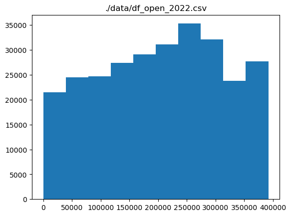

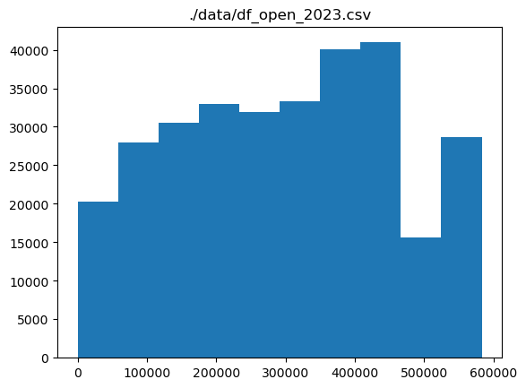

```python
list_df = ["./data/df_open_2022.csv","./data/df_open_2023.csv"]
for df in list_df:
    data = pd.read_csv(df)
    plt.hist(data["overallScore"])
    plt.title(df)
    plt.show()
```

For questions (d) and (e), use the following table:

[figure not shown]

(d) Loops with multiple lists

- Create three lists

list_lower = [93, 90, 87, 83, 80, 77, 73, 70, 67, 63, 60, 0]

list_upper = [100, 92, 89, 86, 82, 79, 76, 72, 69, 66, 62, 59]

list_letters = ["A","A-","B+","B","B-","C+","C","C-","D+","D","D-","F"]

- Create a for loop that prints the message:

"If a students gets a grade between .... and ..., their letter grade is ..."

```python
list_lower = [93, 90, 87, 83, 80, 77, 73, 70, 67, 63, 60, 0]
list_upper = [100, 92, 89, 86, 82, 79, 76, 72, 69, 66, 62, 59]
list_letters = ["A", "A-", "B+", "B", "B-", "C+", "C", "C-", "D+", "D","D-","F"]
index = 0
for letters in list_letters:
    print("If a students get a grade between" + str(list_upper[index]) + " and " + str(list_lower[index]) + ", their letter grade is " + letters)
    index = index+1
```

```
If a students get a grade between100 and 93, their letter grade is A
If a students get a grade between92 and 90, their letter grade is A-
If a students get a grade between89 and 87, their letter grade is B+
If a students get a grade between86 and 83, their letter grade is B
If a students get a grade between82 and 80, their letter grade is B-
If a students get a grade between79 and 77, their letter grade is C+
If a students get a grade between76 and 73, their letter grade is C
If a students get a grade between72 and 70, their letter grade is C-
If a students get a grade between69 and 67, their letter grade is D+
If a students get a grade between66 and 63, their letter grade is D
If a students get a grade between62 and 60, their letter grade is D-
If a students get a grade between59 and 0, their letter grade is F
```

(e) Classification with double loops

- Suppose that 7 students get the following grades:

list_studentgrades = [84, 62, 92, 74, 97, 80, 79]

- Print the following message:

"The student got a numeric grade of .... and their letter grade was ..."

```python
list_studentgrades = [84, 62, 92, 74, 97, 80, 79]
for grade in list_studentgrades:
    index = 0
    for letter in list_letters:
        if (grade >= list_lower[index]) & (grade <= list_upper[index]):
            print("The student got a numeric grade of " + str(grade) + " and their letter grade was " + letter)
        index = index + 1
```

```
The student got a numeric grade of 84 and their letter grade was B
The student got a numeric grade of 62 and their letter grade was D-
The student got a numeric grade of 92 and their letter grade was A-
The student got a numeric grade of 74 and their letter grade was C
The student got a numeric grade of 97 and their letter grade was A
The student got a numeric grade of 80 and their letter grade was B-
The student got a numeric grade of 79 and their letter grade was C+
```